# Visualising Parking Violations in NYC

## Data

NYC Open Data has data on all [parking violations issued in NYC](https://data.cityofnewyork.us/City-Government/Parking-Violations-Issued-Fiscal-Year-2021/pvqr-7yc4) since 2014. The entire dataset currently contains over 10 million observations. In order to make the process of analysis more manageable, a subset of tickets issued from January 2020 to January 2021 and in Manhattan precincts only is selected. This yields about 2.2 million parking tickets or observations.

The main file `parkingNYC_Jan2020-Jan2021.csv` contains the details of all parking violations during the specified time period. The supporting file `parkingViolationCodes_January2020.csv` contains the codes denoting the different types of parking violation and their corresponding fines. Shape files of all the police precincts in NYC are also available.

### 1. Exploring Basic Patterns in the Data

#### 1.1. Top 10 Violations by Frequency and Revenue Generated

Firstly, I determined the top 10 violations by both frequency and revenue generated. This is useful to get a sense of the different types of violations and the extent to which they are problematic. I used ordered dotplots to visualise the top violations as they are good for highlighting ranking and are easy to read.

Figure 1 show the 10 most common violations in terms of frequency. The most frequent violation is ‘No-Standing - Day Time Limits’ and the 10th most frequent violation is ‘Expired Money Meter’.

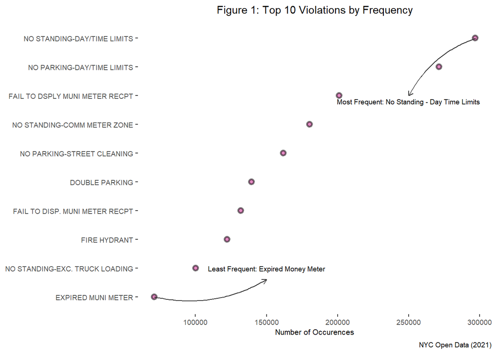

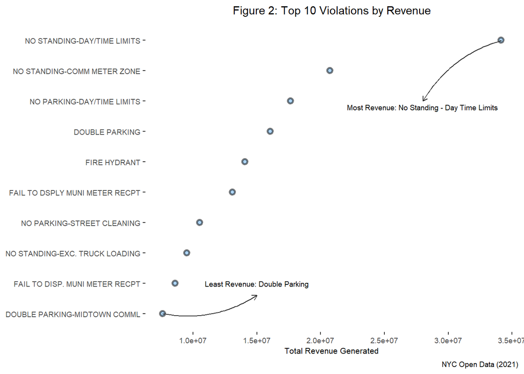

From the plots above, it is clear that there a few broader types of violations such as `No Standing` and `No Parking` and various sub-types of violations within them. An alternative approach to getting an overview of the parking violations dataset would be to group various sub-types of parking violations into broader categories before creating visualisations of top violations.

#### 1.2 Average Fines by Vehicle Colour, Year, and Plate Type

There are many spellings of vehicle colors. The ones chosen for analysis are the top 10 colors in their most complete spellings. Assuming the spelling errors are random, the exclusion of the other spellings should not affect the analysis too much. Brown cars have the highest average fine and beige cars have the lowest according to the analysis shown in Figure 3.

[output not shown]

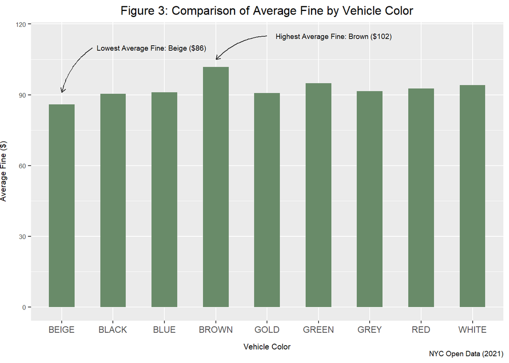

```
##  [1] 2019 2014 2018    0 2020 2016 2012 2010 2007 2004 2015 2017 2013 2008 1996
## [16] 2011 2005 2006 2002 2009 2003 1997 2001 1993 1998 1999 2045 1995 1987 1994
## [31] 1974 1989 1984 1992 2021 1991 1972 1988 2066 1986 1971 1973 1990 2065 2069
## [46] 1979 1980 1970 1983 1977 1982 1985 1978 2067 2022 1976 2064 2063 1981 1975
## [61] 2068 2041 2062 2025 2030 2028 2056 2036 2053 2058 2049 2060 2040 2061 2043
## [76] 2051 2057
```

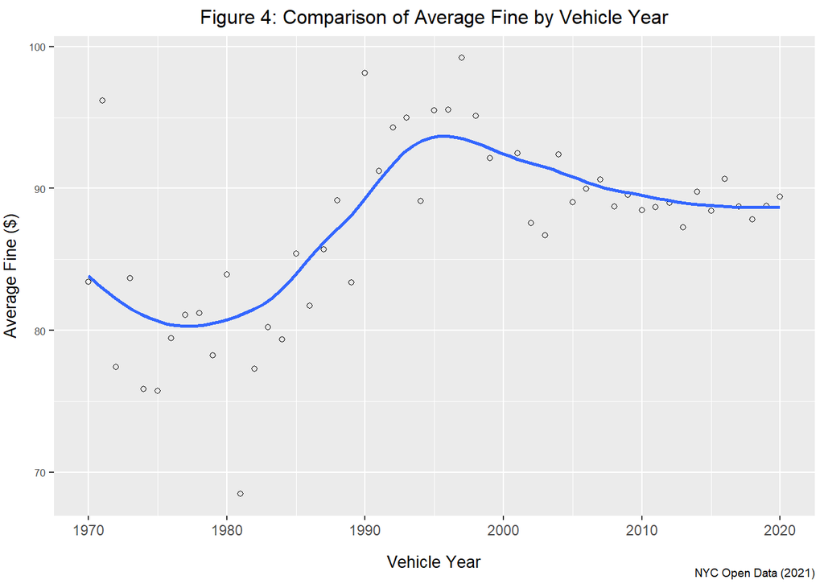

The analysis just focuses on the `COM` and `PAS` plate types. From Figure 5, it can be seen that the `COM` plate type has a higher average fine, but only by a slight amount.

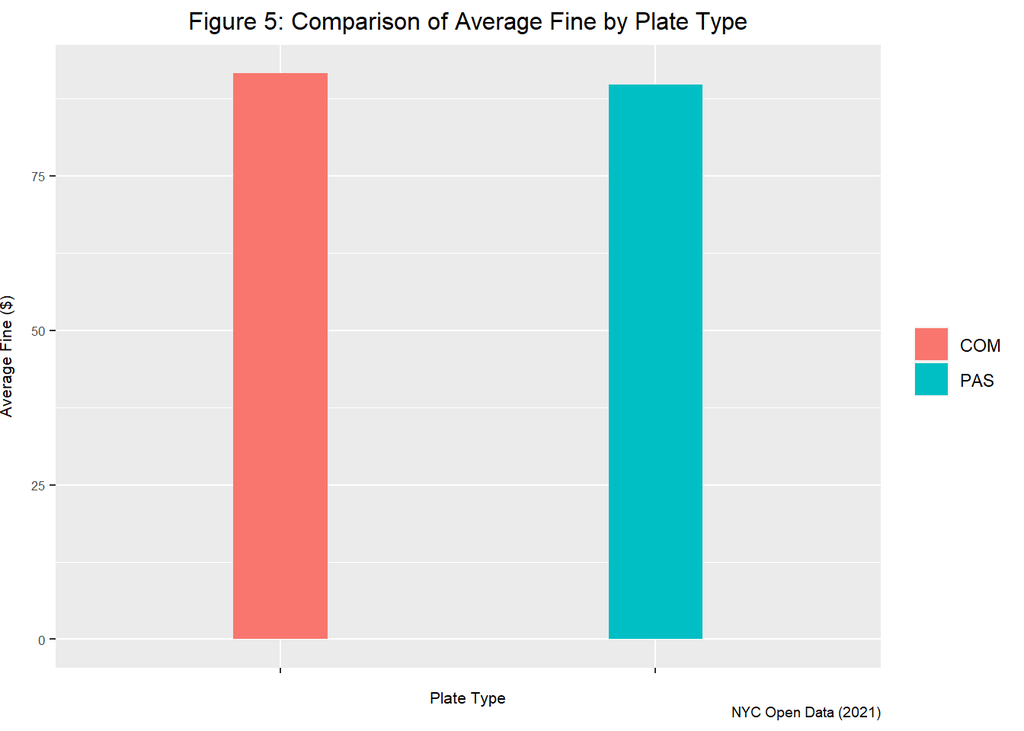

#### 1.3 Effect on COVID on Parking Violations

New York issued a statewide stay-at-home order on 14 March 2020. It would be interesting to see if the restrictions had any effect on parking violations.

Figure 6 appears to indicate that the stay-at-home restrictions has no effect on parking violations. There appears to be virtually no change in the number of violations. However, this is not likely to be true as it is natural to expect that there would be fewer violations due to fewer people being present outdoors. Hence, the time period of analysis will be reduced further.

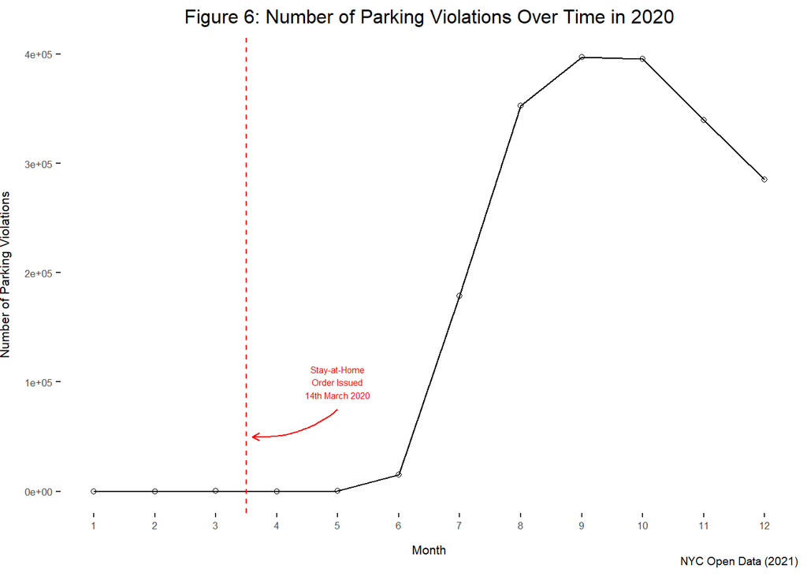

Figure 7 shows the effect of the stay-at-home restrictions more clearly. There was a 55% decrease in the number of violations between March and April 2020. This makes sense as people had less reasons to be outside and using their cars.

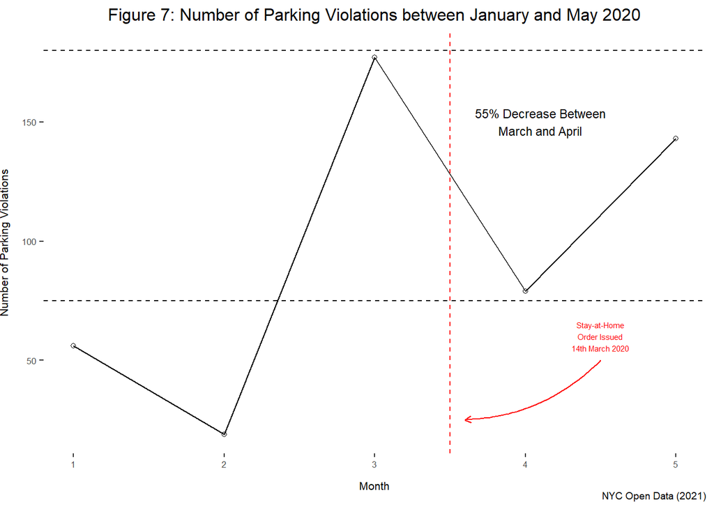

### 2. Static Maps of Parking Violations by Precincts

#### 2.1 Total Tickets, Total Fines, and Average Fines in Different Manhattan Precincts

I created 3 spatial chloropeth maps that show the total number of tickets, the total amount of fines, and the average amount of fines respectively in the Manhattan precincts.

There are more violations as one moves downtown compared to uptown in general. This is probably because the downtown area is more congested and has less parking spaces. The area uptown is slightly more spacious and people are able to park without violating parking regulations. The Upper East Side is the biggest source of violations.

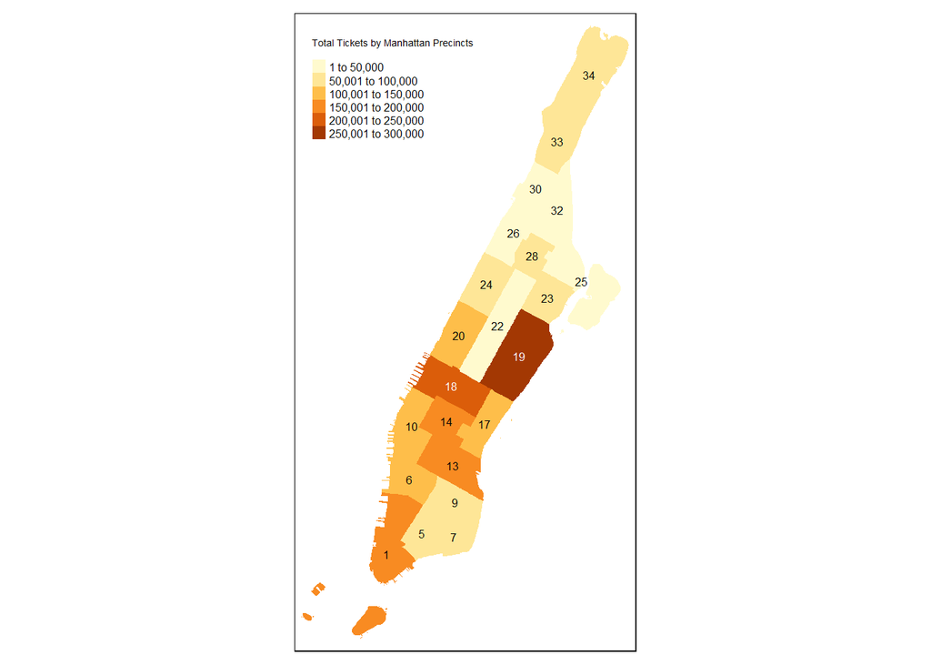

The total amount of fines collected is highest in the downtown area which makes sense as there are more violations there. The Upper East Side, which had the greatest number of violations, is the biggest source of revenue.

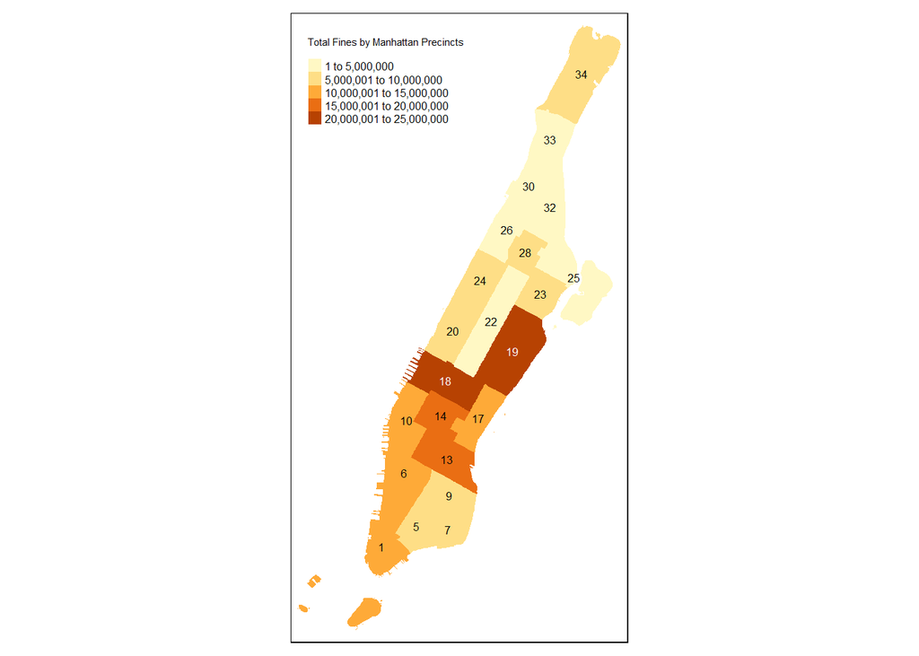

The average fines collected are highest around midtown and central Park area. This could be because the area has a lot of museums and tourist attractions.

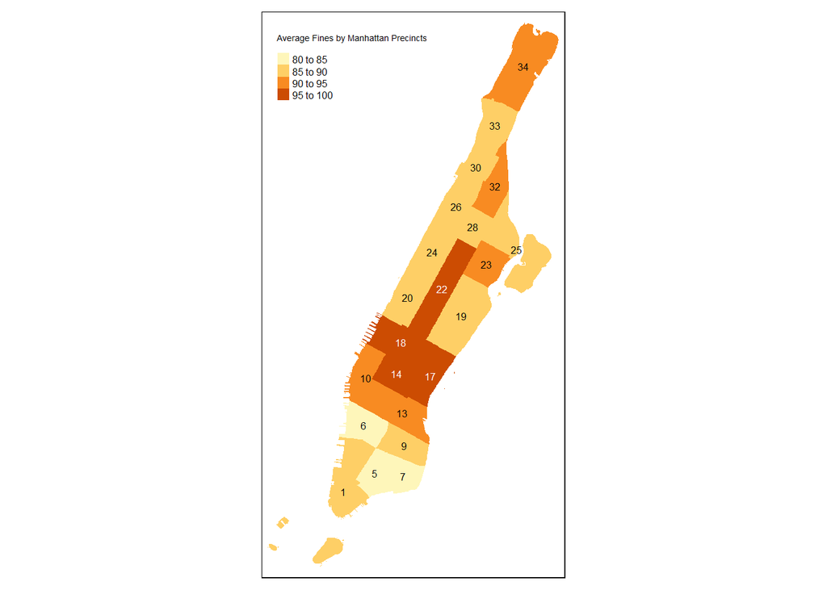

#### 2.2 Relative Occurence of Different Violation Types in Different Manhattan Precincts

The almost 100 types of ticket violations are grouped into a smaller set of subgroups. The 4 groups are `NO STANDING`, `NO PARKING`, `EXPIRED METER`, and `OTHER`. All violations are grouped into one of these 4 sub-groups. I have used choropleth maps for each of these subgroups to show where different types of violations are more or less common.

‘NO STANDING’ violations are more common in the midtown and downtown regions than uptown. Precinct 18 is the most common area for these violations.

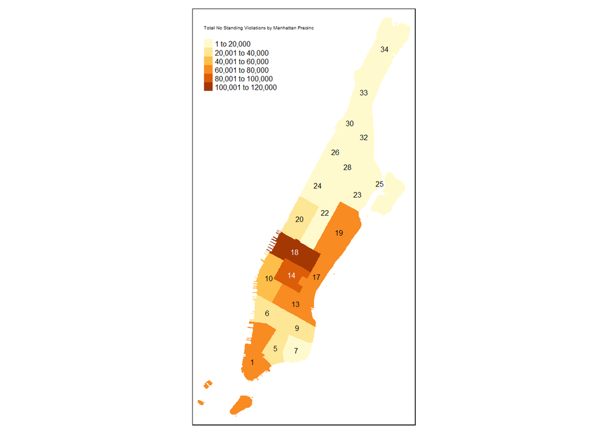

‘NO PARKING’ violations are most common in the Upper East Side and downtown.

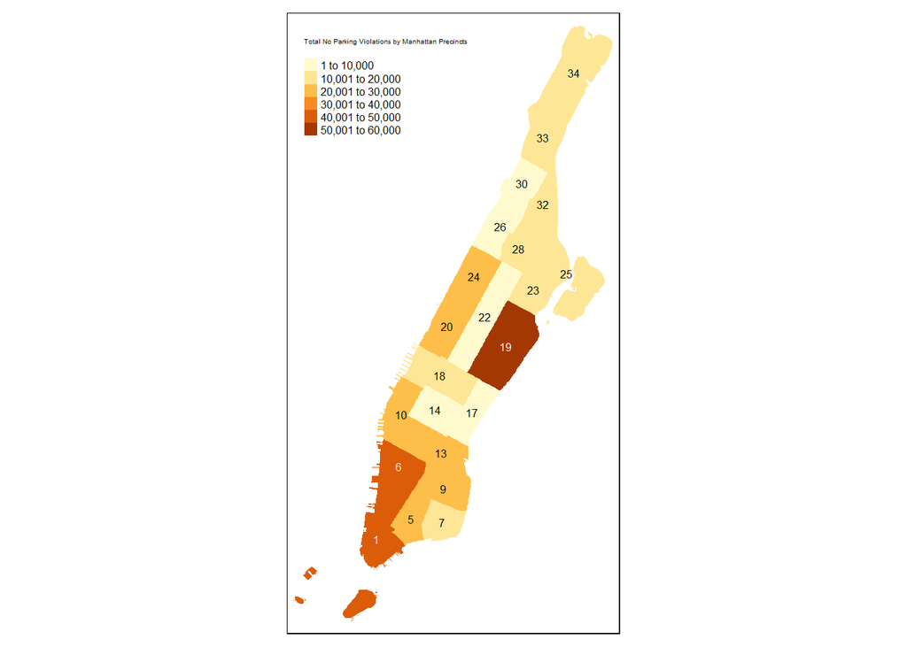

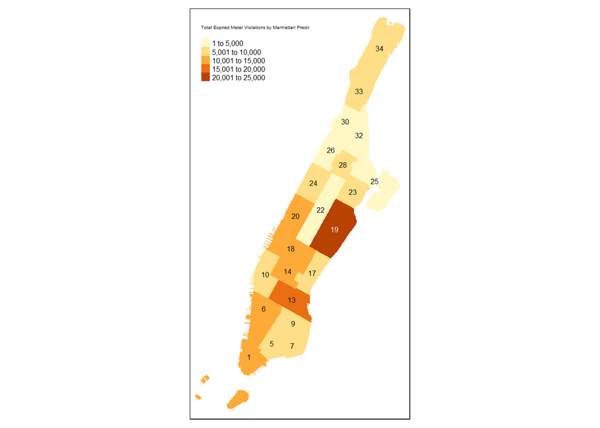

‘OTHER’ violations are most common in the Upper East Side

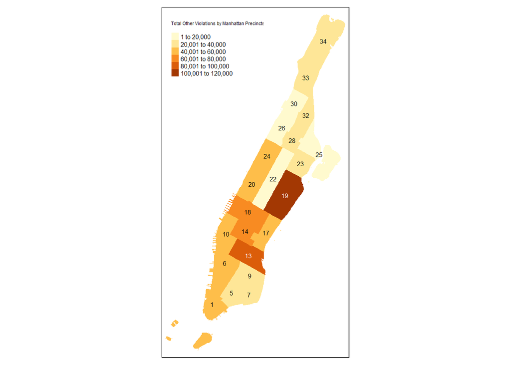

### 3. Focusing on the Upper East Side

As seen from the previous plots, the Upper East Side is the largest source of parking violations and revenue related to that. Hence, I will be focusing on just that region on Manhattan for the next few plots.

#### 3.1 Locations of Parking Violations Related to Fire Hydrants

Using the information on the street name and house number, I geocoded 500 addresses for parking violations related to fire hydrants using OpenCage. The data table below lists the addresses where the violations occurred and the latitude and longitude of those addresses.

The data table has been given below.

|  | Address | Latitude | Longitude |
| --- | --- | --- | --- |
| 1 | 170 E 73rd St Upper East Side of Manhattan | 40.7706032 | -73.9610615 |
| 2 | N E 59th St Upper East Side of Manhattan | 40.759667 | -73.9620467 |
| 3 | 790 Madison Ave Upper East Side of Manhattan | 40.768494 | -73.9680208 |
| 4 | 944 Park Ave Upper East Side of Manhattan | 40.7647425 | -73.9683181 |
| 5 | 516 E 79th St Upper East Side of Manhattan | 40.7838618 | -73.9799918 |
| 6 | 238 E 95th St Upper East Side of Manhattan | 40.78343 | -73.96625 |
| 7 | 172 E 73rd St Upper East Side of Manhattan | 40.7705864 | -73.9609687 |
| 8 | 238 E 95th St Upper East Side of Manhattan | 40.78343 | -73.96625 |
| 9 | 744 Madison Ave Upper East Side of Manhattan | 40.7670983 | -73.9689741 |
| 10 | S E 74th St Upper East Side of Manhattan | 40.7710532 | -73.9596512 |

[output cut: 490 more lines]

#### 3.2 Interactive Maps from Geocoded Addresses

I created interactive maps from the geocoded addresses above. The address of the violation, date issued, vehicle make and plate type are provided in a popup. From the plot below, it can be seen that the geocoding done earlier is not completely accurate as some of the locations are in the Upper West Side instead.

[interactive chart not shown]

Start with the previous map, I distinguished the points by whether the car is a repeat offender (Plate ID appears more than once in the given time period) and a luxury car (a few car brands are considered luxury for this exercise). The legend informs the user about the color scheme. The information related to the violation is provided in popup.

[interactive chart not shown]

Marker clustering is added to the map produced earlier such that zooming in will reveal the individual locations while the zoomed out map only shows the clusters.

[interactive chart not shown]